# How to 'make cycling soar': A geographical exploration of the factors associated with changes in bicycle commuting in England between 2001 and 2011

Bicycle commuting offers a range of health benefits now and in the future. In the short term, cycling to work is an important source of exercise for an increasingly sedentary population. Longer term health benefits may arise through reduced levels of climate change and dependence on fossil fuels. Despite the strength of evidence about these benefits, there is still a dearth of geographical information about the environmental factors and local policies that are effective. This paper processes data from the 2001 and 2011 UK Census to calculate the dependent variable: *change* in the proportion of commuters cycling to work across England's 324 Local Authorities. Data on average income, cycle paths, safety and central government spending on cycling were used to explain variation in the dependent variable. Average income, investment and a low proportion of commuters driving to work in 2001 were significant in explaining cycle uptake. The findings will be of use to policy makers looking for an evidence base on which to allocate future cycling investments, including the need to focus more on low-income areas.

Keywords: cycling, bicycle commuting, geographic variation.

# Introduction

During the early years of the 21st century the nature of threats to the long-term well-being of the planet and its inhabitants have become increasingly clear. We have more data than ever about the problems, from satellites monitoring the impacts of climate change ([McMillan et al., 2014](http://onlinelibrary.wiley.com/doi/10.1002/2014GL060111/abstract)) to detailed global statistics on likely decline rates of unconventional oil and gas supplies ([Hughes, 2013](http://www.nature.com/nature/journal/v494/n7437/full/494307a.html)). Yet collectively humanity seems unable to act on these cues, raising the spectre of past civilisational collapse and potentially bleak prospects for future generations ([Beddoe et al., 2009](http://www.pnas.org/content/106/8/2483.abstract); [Ehrlich and Ehrlich, 2013](http://rspb.royalsocietypublishing.org/content/280/1754/20122845.full)).

The current energy predicament is often framed in purely environmental terms yet climate change and resource depletion are likely to have substantial negative impacts on human health ([McMichael et al., 2006](http://www.thelancet.com/journals/lancet/article/PIIS0140-6736%2806%2968079-3/abstract)). On the other hand, some proposals to reduce reliance on fossil fuels have potential health benefits ([Cifuentes et al., 2001](http://www.sciencemag.org/content/293/5533/1257.short)). Nowhere is this more noticeable than in the transport sector where the replacement of motorised modes by walking and cycling could provide physical activity to increasingly sedentary populations ([Michaelowa and Dransfeld, 2008](http://www.sciencedirect.com/science/article/B6VDY-4R00FMB-4/2/82bae464d0f4e053ced6751f608cbff9); [Gross et al., 2009](http://www.ukerc.ac.uk/support/TransportReport); [Jarrett et al., 2012](http://www.ncbi.nlm.nih.gov/pubmed/22682466); [Woodcock et al., 2009](http://www.ncbi.nlm.nih.gov/pubmed/19942277))

Although the problems of sedentary lifestyles and fossil fuel dependence are well understood, effective solutions are elusive. In some instances unintended consequences have led to 'solutions' that worsened the situation while leaving the root causes un-addressed (e.g. [Sheehan, 2009](http://dx.doi.org/10.1016/j.copbio.2009.05.010)). Various theories have been developed to explain our collective failure to change direction ([Berners-Lee and Clarke, 2013](http://www.burningquestion.info/)). Generally these revolve around a failure to understand that long-term problems at the interface between the human economy and the Earth's physical systems are entrenched, complex and interdependent ([Smil, 2008](http://mitpress.mit.edu/books/energy-nature-and-society)).

It is within this wider context that questions of transport and health should be considered (Woodcock et al., 2009). The 'global energy challenge' ([Lewis and Nocera, 2006](http://www.pnas.org/cgi/content/long/103/43/15729)) and associated long-term health implications form the backdrop of this paper. Rather than tackle the issues head-on, this paper focusses on one area of policy where reductions in energy use have great potential to improve health outcomes and improved quality of life more generally: personal travel. The research is targeted in terms of its geographic scope (focussing solely on England), time scales (analysing shifts over a decade) and type of travel (focussing on commuting), but relevant to the global context.

Framed in this way, cycling to work is relevant to discussions of humanity's short term well-being and longer term survival: the full benefits of a shift to cycling now may only be realised in the future. A striking feature of the bicycle is that it is a highly accessible technology (almost everyone worldwide can realistically aspire to own one), yet it tackles a very wide range of issues (Komanoff, 2004). Interventions that can simultaneously provide health, energy, economic and social benefit are the mythical 'golden bullets' that policy makers dream of yet almost never encounter. Switching from driving to cycling is just such a 'win-win' solution (Robinson, 2005). It helps solve an array of issues in one simple step. Indeed, the sustainability challenge can be seen as an overinflated balloon: squeeze one area of it and a bulge generally appears elsewhere (Berners-Lee and Clarke, 2013).

This paper starts from the premise that cycling is a desirable outcome for health and other reasons. There is much research supporting this premise and the benefits of active travel more broadly. Less research investigates which policies are most likely to boost cycling in different places at the sub national level (Fraser and Lock, 2011). International comparative studies have helped explain why cycling flourishes in some countries whilst barely accounting for 1% of trips in others (Pucher and Buehler, 2008). A growing body of research seeking to explain variation in bicycle use between smaller administrative zones (see the Literature Review section).

The conditions associated with growth in cycling is a policy relevant area of knowledge about which more evidence is needed (Fraser and Lock, 2011). A central motivation of this paper is to provide information to help fill this 'knowledge gap'. The aim is to inform the policy making process by supplying evidence about which important factors are within the scope of local transport planners to influence. (For example, if topography and weather are found to completely explain growth in cycling, there is little transport planners can do compared with if provision of cycle paths is found to explain much of the change.) Within this question, the following hypotheses were generated, based on the literature on the spatial distribution of cycling (see the literature review below). The expectations were, certeris parabis (all things being equal), that:

- Areas with high incomes would see disproportional increases in cycle commuting.
- Length of cycle paths (a proxy for investment in cycling) will be associate with higher than expected growth rates in cycling.
- A good safety record on cycling (relative to the number of bicycle commuters) will be associated with high growth rates.
- Areas that had received central government support for cycling, through the Cycling Demonstration Towns initiative, would see growth in cycle commuting.

## The benefits of cycling

Unlike some other types of environmental intervention, there are no major downsides to bicycle uptake: cyclists (often unwittingly) provide many benefits to the wider system whilst simply enjoying a fast and healthy for of transport. To be specific, there is strong evidence of social, environmental and economic benefits of cycling in the following areas:

- Improved health of cyclists ([Oja, 2011](http://www.fietsersbond.be/sites/default/files/Heath%20benefits%20of%20cycling%20REVIEW%20%28Oja%202011%29.pdf); [Rojas-Rueda et al., 2011](http://www.creal.cat/media/upload/pdf/articledavidrojas_editora_2_217_1.pdf); [Saunders et al., 2013](http://dx.plos.org/10.1371/journal.pone.0069912)).
- Economic benefits at the individual level, for example due to lower trip times ([Borjesson and Eliasson, 2011](http://www.researchgate.net/publication/228341559_The_value_of_time_and_external_benefits_in_bicycle_cost-benefit_analysEs/file/e0b495165b88274e0c.pdf)), and reduced car use (Semlyen, 2005).
- Economic benefits for society at large via reduced public health bills ([Rutter et al.,2013](http://www.sciencedirect.com/science/article/pii/S0749379712007301); Jarrett et al.,2012) and wider impacts (Cavill et al., 2008; Krizek, 2007; Saelensminde, 2004).
- Environmental benefits including lower greenhouse gas emissions and demand for roads and motor vehicles ([Lenzen, 1999](http://www.sciencedirect.com/science/article/B6VH8-3WMK47K-4/2/707d71a2636a20c4e40d703ae128b1c7); [Lindsay and Macmillan, 2011](http://onlinelibrary.wiley.com/doi/10.1111/j.1753-6405.2010.00621.x/abstract;jsessionid=111BFA6034AF092673E1C985C07238E8.f01t04?deniedAccessCustomisedMessage=&userIsAuthenticated=false); [Lovelace et al., 2011](http://linkinghub.elsevier.com/retrieve/pii/S0301421511000620)).
- Reduction in congestion during rush hour - this is a particular benefit of cycle commuting (as opposed to leisure cycling) via improved traffic flow (Arnott et al., 2005; Downs, 2004).
- Bicycles pose a lower risk to other road users than do cars, with benefits for social equality (Jacobsen et al., 2009; Furness, 2010).
- 'Wide boundary' impacts including heightened sociability of public space and the hope that society may one day be able to operate without burning valuable finite resources (Furness, 2010; Komanoff, 2004; Sustrans, 2012).

## Pro-cycling policies: a UK perspective

Due in part to these benefits, there has been a noticeable increase in political commitment to cycling in many countries, as exemplified by rapid growth in public investment in bicycle share schemes (Fishman et al., 2013). In the UK, for example, Prime Minister David Cameron announced that “we want to see cycling soar” ([Prime Minister's Office, 2013](https://www.gov.uk/government/news/government-shifts-cycling-up-a-gear)) as well as providing a more specific statement of intent: “This government wants to make it easier and safer for people who already cycle as well as encouraging far more people to take it up” (ibid).

Within this context of widespread political and academic support of policies to promote modal shift to cycling, a major barrier is specific evidence on the effectiveness of different interventions. Clearly, the number of new cyclists resulting from a new bicycle path or policy cannot precisely be known. However, using an analogy from medicine, 'dose-response' type studies can greatly help predict the impact of planned interventions (Pucher et al.,2010). Transport planning is a long-term process with even longer-term impacts and such evidence can aid the strategic decision making process (Schweizer and Rupi, 2014) With limited public funds, it is critical to maximise the cost-effectiveness ratio of cycle-related expenditure.

# Literature review: the spatial distribution of cycling

A systematic review of the impact of various policy relevant factors on cycling was undertaken by Fraser and Lock (2011). This paper condensed the literature on the subject down to 21 papers. Of these, 11 found statistically significant relationships between environmental factors and the *rate* of cycling (not growth in cycling, as reported in this study). Cycle paths, land use, distance of trip and the presence of green space were the only factors found to be significantly correlated with cycle use in more than one study, leading to the conclusion that more studies are needed to explore the impacts of different policies and environmental conditions on cycling uptake (Fraser and Lock, 2011). This paper fits into this call for evidence, with an *ecological* (administrative zones are the unit of analysis) appraisal of the impact of different variables in change in cycling to work, based on Census data.

The Census travel to work statistics have been used in many studies to investigate the spatial distribution of travel patterns overall (e.g. Titherage and Hall, 2006). However, the number of studies focussed on active travel, and cycling in particular, is much lower. Goodman (2013) provides a detailed and up-to-date account of the spatial distribution of walking and cycling at the national level across England and Wales and describes how it has changed between 2001 and 2011. The overall rate of walking and cycling to work was found to have changed little, but important regional differences were identified: at the regional and local authority level cycling growth was largely concentrated in high density urban centres, notably London and Bristol. The paper also provided new insight into the shifting social distribution of travel to work mode: affluence is associated with motorised modes, although this association is weakening. Walking and cycling was found to have grown most in the least deprived areas, with car use tending to fall in the wealthiest areas (Goodman 2013). The underlying reasons for these shifts was not explored: “Future analyses could also explore associations with geographic factors such as hilliness, climate and land use patterns; although outside the scope of this paper, these may play a key role in explaining local and regional variation” (Goodman, 2013, p.9). The present paper follows this suggestion by exploring the factors associated with growth in bicycle commuting.

Multivariate regression models have been used to help explain the spatially uneven distribution of the proportion of commutes made by bicycle. Parkin et al. (2008) used a logistic regression model to identify the most important factors related to cycling at the ward level in England and Wales. 81% of the variability in the proportion of commuters cycling to work could be explained by the model. The proportion of white male commuters (positive), number of cars per household (negative) and income deprivation (negative) were found to be powerful socio-economic explanatory variables. Interestingly, hilliness was found to have a negative impact on cycle commuting in the model. Road traffic (via the proxy 'transport demand intensity') was negatively related to cycling to work whereas the proportion of off-road routes had a positive impact. These latter findings indicating transport infrastructure is an important policy area for encouraging cycling.

Another useful output from this paper was the estimation of a 'saturation point', referred to as 'carrying capacity' in population ecology (Lovelace et al., 2011), a theoretical upper limit on the proportion of people cycling to work in any particular area. This was calculated to be 43% of trips, higher than any wards in the UK, but comparable with the proportion cycling to work in some Dutch areas (Parkin et al., 2011).

# Data

British Census data on commuting provided the dependent variable for this paper. The Census was chosen because it has the greatest spatial resolution of transport data in the UK and the highest response rate and number of participants of any national survey, due to the legal requirement to complete it. Downsides for transport researchers include its inclusion of only one reason for trip (commuting) and poor temporal resolution, although these problems can to some extent be overcome by integrating census data alongside more detail surveys. Recent work suggests that the modal split for commuting is highly correlated with modal split for all trips (r > 0.9 for private modes and public transport, dropping to r = 0.77 for cycling), indicating that commuting may be a reasonable proxy for travel behaviour overall (Goodman2013). In addition, the annual publication of results from the [National Travel Survey](https://www.gov.uk/government/collections/national-travel-survey-statistics) provide higher temporal resolution to complement the 10 year cycle of the census.

The input data for the independent variable were tables of commuter mode share by administrative zone between the 2001 and 2011 Census. England was used instead of the wider area of Great Britain because the compatibility issues associated with comparing spatial units is made more complex with the addition of Wales and Scotland. In the case of Scotland, travel to work data are not available on the data dissemination portal Casweb. An additional reason for excluding Scotland and Wales from the analysis is that they have different travel to work characteristics than England, with much lower population densities and generally levels of isolaiton and car reliance (Gray et al., 2001; Nutley, 1980).

A data problem that had to be overcome early in the analysis was the conversion of 2001 354 Local and Unitary Authorities (combined with the 'merge' function in QGIS) into 2011 local authority areas (LAs), composed of English Districts, Unitary Authorities and London Boroughs. As shown in Fig. 1, there are 8 2011 LAs which encapsulate many (38) 2001 administrative zones. The result of this process of spatial aggregation was all 324 'lower tier' 2011 LAs, for which the travel to work data was directly comparable between 2001 and 2011.

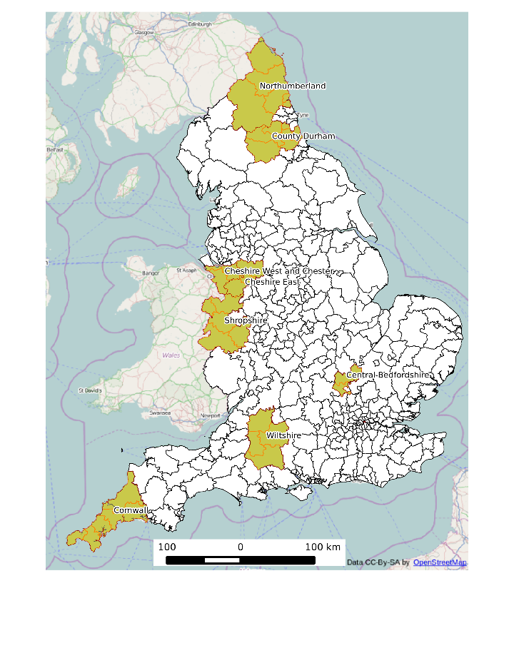

The data pre-processing for these areas was simpler as there has been less change between 2001 and 2011 for Output Areas than other types of administrative geography. Of the 6,781 2001 MSOAs, 98% (6,640) are unchanged in the 2011 dataset. The remaining 141 zones are contiguous with the more numerous (n = 6791) 2011 zones (Fig. 1). Because many of 2001 MSOAs were split-up into small 2011 zones, the solution was not as simple as allocating the misfits to the nearest 2011 zones. Instead, we took advantage of the unchanging geometry of the OA zones and calculated incomplete records by aggregating 2001 data from OA-zones in each incomplete 2011 zone.

The explanatory variables used in the baseline model to test the hypotheses listed in section 1 were:

- *Avinc*, the mean average income for households in each area, downloaded at the MSOA level from the official data repository [data.gov.uk](http://data.gov.uk/dataset/household_earnings_estimates_-_model-based_estimates_of_income_for_msoas).
- *Lpath*, the of high quality cycle paths within each area. This dataset was provided in a series of MySQL databases by CycleStreets.net and processed in R. To ensure high quality paths were selected, only those with CycleStreets' 'quietness' and 'speed' variables above the median were selected.
- *Bcrash*, a proxy for the safety record in each area. This was defined as a severity-weighted count of the number of cycle-related road traffic incidents reported in the STATS19 database from the beginning of 2005 until the end of 2012.
- *CDT*, a crude proxy of investment in cycling in each zone, defined as a binary variable: 0 for areas outside the scope of the CDT project and 1 for areas that did receive funding.

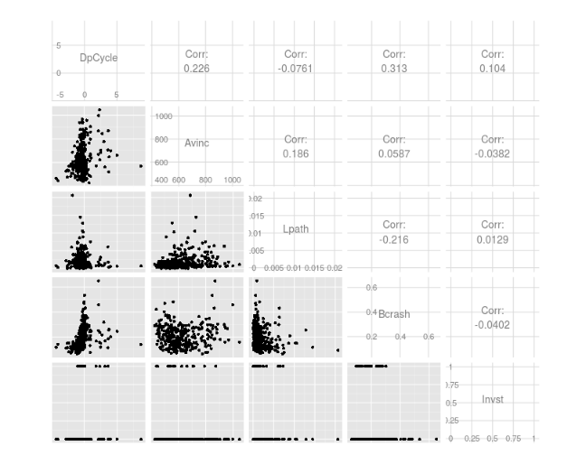

## Additional variables

In addition to these baseline input datasets, a number of other variables were tested to investigate the relationship between other variables and cycling to work. These were, in order that they were tested:

- The proportion of trips made by car in 2001 (\( pCar \))
- The change in the proportion of young (18 - 39), white males in each area, 2001 to 2011 (\( \Delta pYWM \)), following Parkin et al. (2008) who found this to be an important explanatory variable.
- The number of cars per household in 2001 (\( carOwn \)) and change in car ownership (\( \Delta carOwn \))

# Method

In line with the principle of parsimony, the modelling approach was to start simply, by reporting key statistics about changes in cycle commuting in England, before progressing to a regression model.

The proportion of people cycling to work (*pCycle*) was calculated as the total number of bicycle commuters (\( Cycle \)) divided the number of people commuting by all modes (\( Commute \)) for each area (\( a \)). At the national level, this can be represented as the population-weighted sum of *pCycle* for all areas:

\[ PCycle = \frac{\sum_{a=1}^n pCycle_a Commute_a}{\sum_{a=1}^n Commute_a} \]

where \( PCycle \) is the proportion cycling overall and \( pCycle_a \) is the proportion cycling in each area. This is expressed more concisely as the total number of cyclists divided by the total number of commuters (\( PCycle = Cycle / Commute \)). However, the above equation is useful in demonstrating how a single national value can mask substantial regional variation and highlights the importance of a zone's total population: while the *average* value of *pCycle* dropped from 3.3 to 3.1% across English LAs from 2001 to 2011, *PCycle* remained constant. In other words cycling grew in the (urban) LAs with higher than average populations.

The categories of “unemployed” and “work from home” were deliberately excluded from the \( Commut \) count, to prevent changes in employment structure influencing the result: if a commuter belt shifted away from car driving towards 'teleworking' (working from home), for example, this method could provide an unfairly optimistic impression of the uptake of cycling.

A linear regression model was used to test the impact of the explanatory variables on model fit, and to elucidate the direction of influence. Following the principle of parsimony in model design, a simple model based on the hypotheses presented in the introduction was developed first. Against this baseline the performance of different model runs was compared. To this end the following alterations were made:

- Changes to the number and type of explanatory variables used.
- Subsetting the observations used for the model (e.g. to exclude London)
- Altering the dependent variable itself to explore the relationship between absolute and relative increases in cycling.

# Results

The rate of cycling between 2001 and 2011 census was found to have changed very little, being 3.1% in both cases. However, there was substantial variation between the zones in terms of change in cycling. There is a strong positive skew in the distribution the growth rate (Fig. 3): less than a quarter (74) of LAs saw the modal share of cycling rise, by an average of 30% whereas the majority of LAs (250) saw small declines in the proportion of people cycling.

In terms of absolute growth, the distribution is more symmetrical, with the vast majority of zones (264 zones, 81%) seeing less than a 1% change either way in absolute proportion of people cycling to work. These results are plotted geographically in Fig. 4.

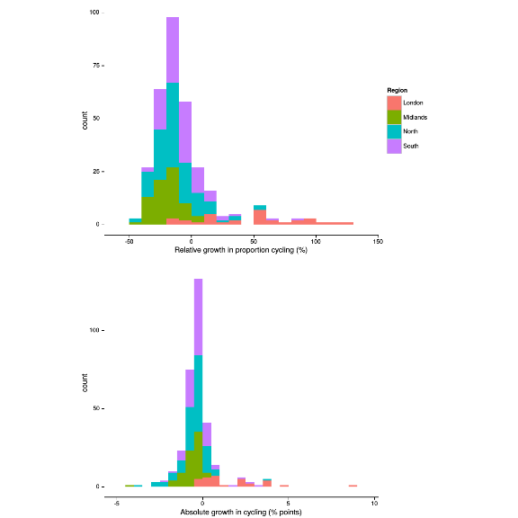

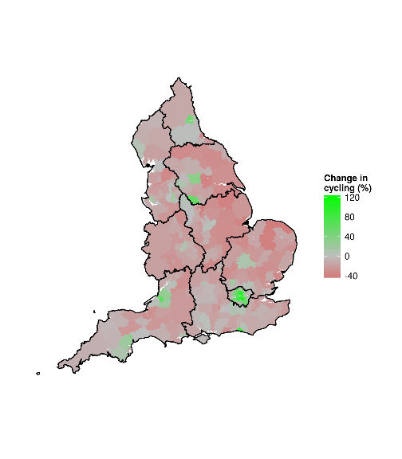

It is interesting to note that the average cycling rate in 2001 was lower for zones where cycling dropped (3.3 %) compared with zones where cycling grew (3.7%). Indeed, the variability in the proportional of people cycling grew between 2001 and 2011, despite the mean remaining the same: the standard deviation increased from 2.5 percentage points in 2001 to 2.7 in 2011. At the MSOA level the standard deviation of the percentage of people cycling to work also grew noticeably, from 2.7 to 2.9.

The regional distribution of growth in cycling, with its focus on London, is also evident from fig 5, which shows the expected high correlation between the percent cycling to work in 2001 and 2011 (r-squared = 0.82). The \( x = y \) line in Fig. 5 represents the 'break even' point above which cycling has grown and below which it has dropped. Thus, there are 74 points above the line and the rest fall below. The further points are located from this break even line the more cycling has changed in that area. The colours illustrate that many of the zones with the greatest growth in cycling are located within the Greater London Authority.

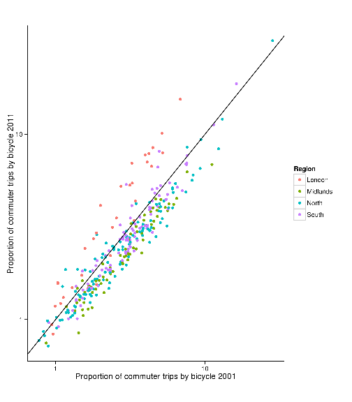

The regional pattern represented by the colours in Fig. 5 is emphasised in Table 1, which shows that outside London there were falls in the proportion of people cycling to work, with the greatest declines in the Midlands and the North: the average LA in the Midlands saw the proportion of people cycling to work drop by a fifth.

Table 1: regional differences in the change in cycling as a commuter mode in England, 2001 to 2011.

| Region | Relative change | Absolute change |
| --- | --- | --- |
| London | 47.4 | 1.6 |
| Midlands | -19.7 | -0.7 |
| North | -12.3 | -0.5 |
| South | -7.8 | -0.2 |

Because of this apparent “London exceptionalism”, the analysis was re-run with London removed. It was found that outside London, the proportion of all people cycling to work dropped substantially, from 3.2% in 2001 to 2.9% in 2011. *The average LA outside London saw a 12% drop in the proportion of people cycling*. These results suggest that attempts to 'get Britain cycling' have so far failed outside of the capital, which has seen the country's only large 'congestion charge' scheme encourage active travel (nakamura2014economic).

Table 2 presents the growth in cycling in the top 5 and bottom 5 areas in terms of absolute shift in the proportion of people cycling to work. It is noticeable that while 4 of the top 5 received central government funding between 2001 and 2011 from the CDT initiative, none of the bottom 5 did. (Oxford is conspicuously missing from the list of CDT beneficiaries, and some cycle campaigners have accused the local council of failing to properly maintain the city's existing cycle infrastructure ([Horne, 2008](http://www.oxfordmail.co.uk/news/2296153.print/)).) This suggests that, in addition to investment helping to increase the rate of cycling, it can also serve to maintain it and prevent declines in areas that have an already high rate of cycling.

Table 2: Statistics on cycle commuting from the top 5 and bottom 5 local authorities in England in terms of the absolute change in the proportion of commuters cycling to work. Note that 'CDT' refers to central government funding through Cycling Demonstration towns and the value is the year in which the funding was awarded.

| Local Authority | pCycle 2001 | pCycle 2011 | \( \Delta pCycle \) | \( Q pCycle \) | CDT |
| --- | --- | --- | --- | --- | --- |
| Cambridge | 28.3 | 31.9 | 3.6 | 12.7 | 2009 |
| Bristol, City of | 4.9 | 8.1 | 3.1 | 63.7 | 2009 |
| Oxford | 16.2 | 18.7 | 2.5 | 15.5 | No |
| Brighton and Hove | 3.0 | 5.3 | 2.4 | 80.1 | 2005 |
| Exeter | 4.8 | 6.6 | 1.8 | 37.3 | 2005 |
| :—————————- | ———: | ——-: | ———–: | ——-: | :——— |
| Boston | 11.1 | 6.9 | -4.3 | -38.4 | No |
| Hull | 12.3 | 8.3 | -4.0 | -32.2 | No |
| Waveney | 9.3 | 6.5 | -2.7 | -29.6 | No |
| Fenland | 7.4 | 4.9 | -2.6 | -34.4 | No |
| North East Lincolnshire | 8.2 | 5.6 | -2.6 | -31.2 | No |

## Regression model results

The baseline model was able to explain 16% of the variation in \( \Delta pCycle \) and 14% of the variability in \( Q pCycle \) across all zones, with adjusted R-squared (\( aR^2 \)) values of 0.16 and 0.14 respectively. This is a statistically significant by not particularly impressive result. In addition, the most significant variable, \( Bcrash \), had the opposite sign as expected, indicating that cycling may have become proportionally riskier in places where cycling has grown the most (see Table 3). Indeed, the correlation between \( Bcrash \) and \( \Delta pCycle \) was strongly positive (r = 0.31).

We can speculate why this may be - perhaps car drivers in growth areas were relatively unused to high cyclist volumes or perhaps accident rates are higher amongst new cyclists. Yet correlation does not prove causality and the number of cycle commuters is a poor indication of *exposure*, meaning that the results do not show with any certainty that cycling really did tend to become less safe in areas where cycling grew. It is implausible to assume that growth in cycling was *caused* by the increase in *Bcrash* (although the reverse may be true), so this variable was removed from subsequent model runs.

\( Avinc \) and \( CDT \) had a statistically significant (p < 5%) impact on \( \Delta pCycle \) in the baseline model in the direction expected. \( Avinc \) had a strong positive correlation with \( \Delta pCycle \) (r = 0.22) and \( Q pCycle \) (r = 0.21). Despite there being only 17 CTD projects (their impact spread across 19 LAs), the impact on the model was statistically significant: CDT funding increased the proportion of people cycling in an LA by on average 0.6 % points in the baseline model. To explain a greater proportion of the variability in change in cycling to work, the additional variables were added in place of *Bcrash*.

Table 3: Results from the baseline model.

| Variable | Estimate | Std. Error | t value | P |
| --- | --- | --- | --- | --- |
| (Intercept) | -2.32 | 0.33 | -7.1 | 0.00 |
| Avinc | 0.00 | 0.00 | 4.3 | 0.00 |
| Lpath | -28.08 | 26.88 | -1.0 | 0.29 |
| Bcrash | 3.91 | 0.71 | 5.5 | 0.00 |
| CDT | 0.61 | 0.25 | 2.4 | 0.02 |

## Additional variables

Adding more variables improved the model fit. With \( Bcrash \) removed, the additional variables mentioned in the Data section were tested one by one. The variable that had by far the greatest impact on the model was the proportion of trips made by car drivers in 2001. Replacing \( Bcrash \) with *pCar* in the baseline model meant that half of the variation in \( \Delta pCycle \) could be explained, rising to 2/3 when \( Q pCycle \) was predicted (\( aR^2 \) 0.50 and 0.66, respectively).

Replacing \( pCar \) with \( \Delta pYWM \) led to a poorer model fit, although the variable had a statistically significant impact on the model at the 5% level in the expected positive direction as a predictor of \( Q pCycle \). \( \Delta carOwn \) also had a minimal effect on the model at this stage.

## Removing London

As can be seen in Fig. 5, LAs within London had anomalously high growth rates, some of which can be explained by factors exclusive to the capital such as the congestion charge, slow traffic speeds and an influx of young, mobile workers. A strong case can thus be made for treating London separately. When London was removed, this had a large impact on the baseline model: the *p* value of *CDT* fell dramatically, from 0.02 in the baseline model to less than 1 in 100,000 with London excluded. In addition the slope of the estimated impact of CDT funding increased to 0.8% points.

With London removed, the influence of \( \Delta pCar \) dropped substantially although it was still highly statistically significant in the expected direction. The impacts of the other additional variables were statistically insignificant.

## The final model

The simplest solution that explained a high proportion of variability in cycling to work was chosen. This was found to be the following expression:

\[ Q pCycle \sim Avinc + pCar + CDT \]

Table 4: Results from the final model

| Variable | Estimate | Std. Error | t value | P |
| --- | --- | --- | --- | --- |
| (Intercept) | 55.825 | 8.783 | 6.356 | 0.000 |
| Avinc | 0.032 | 0.008 | 4.178 | 0.000 |
| pCar | -134.211 | 14.078 | -9.534 | 0.000 |
| CDT | 6.803 | 3.424 | 1.987 | 0.048 |

# Discussion

Cycling for personal transport has become more unequal over space in the last 10 years: most of the growth in cycle commuting has happened in London and a few urban centres outside the capital. This coincides with findings of geographical divergence of many other geographic variables related to health and the economy (Dorling, 2011). Excluding London from the analysis, cycle commuting has declined overall from 3.2 to 2.9% of trips. Within this aggregate figure, a few areas have seen very impressive rates of growth in cycling and a number of these received central government funding through the Cyclind Development Towns project. Yet the trend for a typical English LA outside London has been decline: the median value of pCycle dropped by 0.4% points from 2.9 to 2.5%, a worrying trend about which many academics and cycle campaigners seem unaware.

That is not to downplay the success stories, but raises the question: why did cycle commuting in some areas grow against a backdrop of decline? The paper has been able to provide some answers here: areas with high incomes, historically low rates of car use and government support have tended to do well. This does not prove cause and effect: it is plausible to suggest that areas received cycle funding precisely because they were seen as success stories.

Returning to the hypotheses posed in the introduction, we have provided statistically significant evidence that the health and other benefits of cycling are disproportionately being enjoyed in high income areas, where much of the growth has occurred. No significant evidence about the positive influence of safe roads or bicycle path provision was found. More research is needed in both areas and the study has by no means disproved a link.

The findings support previous calls for more rigorous studies exploring the impact of different environments and policies on active travel (Fraser and Lock, 2011). Specifically, there is a need for a database on public expenditure on cycling and an up-to-date database on cycle paths and other pro-cycling features. Only with official high quality databases (or improvements in Open Street Map) will we able to compare the impacts of different interventions.

There are a number of limitations to the study. Using areal units to explain any issue that is ultimately played out at the individual level risks committing the 'ecological fallacy': falsely inferring things about individuals based on aggregated data (Openshaw, 1983). To avoid this problem we have been careful to state that the findings apply only to areas and not necessarily to the citizens who occupy them. We cannot know from the results, for example, that individuals on high incomes are tending to cycle more, just that the number of people reporting cycling to work in areas with high average incomes has grown. There is, however, verbal evidence of the importance of class and cultural identity in the context of cycling growth in wealthy areas (Aldred and Jungnickel, 2014), with which our results coincide.

The research presented in this paper also raises important questions about data quality. From a health perspective, the number of people who use bicycles as their *main* form of transport to work is far less important than the number of people who cycle once or twice per week. The marginal benefit of exercise decreases after a few hours of moderate exertion per week and a roughly typical cycle commute of 3 miles each way could easily reach this amount. More important from a health perspective (and potentially from an environmental perspective) is the number of people who *sometimes* cycle to work, once or twice per week, but not always. Because cycling is often a 'plan B' mode to be used occasionally, the potential impact of under-reporting of trips is large. Conversely, there may be many people who entered cycling as their primary mode of transport to work as 'aspirational cyclists' who cycle occasionally but would like to think that they always do. These questions of data quality require further analysis and the National Travel Survey could provide a useful empirical starting point for future research into this area.

In terms of monitoring the geographical distribution of a shift to cycling, a more suitable independent variable would be the total number of trips taken by residents of each area per year. Even more specifically, estimates of the total distance cycled in each area, and the social distribution of this cycling activity across society as a whole would be preferable. Indeed, if cycling is concentrated amongst healthy men, it is realising only a fraction of the potential health benefits.

# Conclusion

This study provides new evidence about the spatial distribution of uptake and declines in cycling to work across England. Regression analysis at the level of Local Authorities was used to test hypotheses about factors expected to be associated with growth in cycling. Of these, statistically significant results were found for average income and government support for cycling at the level of local authorities. The former supports the wider 'peak car' narrative (Goodwin and Van Dender, 2013). Perhaps more relevant for local policy makers is the latter - that cycling grew significantly *more* in areas which received central government funding through CDTs. This supports additional tranches of central government funding for cycling, especially targetting low income areas.

The study uses *change* in the rate of cycling to work over 10 years as the dependent variable. This differs from most geographical studies on the subject, which generally explain cycling variability at one specific point in time (e.g. Parkin et al., 2008). These studies focus attention on variables that are either inherent to the natural environment (e.g. topology, weather) or which are not easy to alter through policy interventions (e.g. average distance of trips) (Fraser and Lock, 2011).

Amongst these factors, average income was found to be most strongly associated with cycling, providing further evidence that growth in cycling has been driven in recent years primarily by the wealthy (Goodman, 2013). This coincides with evidence from the 'peak car' literature that high income groups are tending to drive less each year (Metz 2013). Of course, the average income of people in different areas is a factor outside the control of most policy makers (although they may wish otherwise). Yet the finding is important in terms of policy design as it provides additional evidence that more needs to be done to promote cycling amongst the most disadvantaged in society (Christie, 2011). The study supports the conclusion that “care needs to be taken to also develop interventions in lower-income areas” (Aldred and Jungnickel, 2014).

An unexpected finding that merits further analysis was that the most powerful predictor of change in cycling was the proportion of people driving to work in 2001. We can speculate about why this may be. The result may be linked to confounding factors such as average distances between home and work locations, for example. In any case strength of the relationship supports the idea that cars and bicycles can be seen in ecological terms as 'species' in direct competition (Lovelace et al.,2011). The policy implication of this finding is that in some cases the best way to promote active travel from a health perspective may be to implement policies discouraging car use (Jacobsen et al., 2009).

The limitations of the study relate to its methodology and use of administrative zones as the unit of analysis. Focussing on reported cycling to work as the dependent variable is problematic because cycling to work is not an either/or decision but something that can vary widely, from every day to a few times per month (Stinson and Bhat, 2004). Such subtleties are simply not collected in the Census: there is a trade-off between geographic resolution and coverage from census data and depth and insight from individual-level surveys. The paper therefore advocates further studies that seek to integrate detailed survey datasets with information from the Census, for example by comparing correlations between Census and individual level variables (Goodman, 2013) or more complex techniques such as spatial microsimulation (Lovelace et al.,2014).

It is clear that more research is needed on how best to promote cycling. Returning to the global issues raised in the introduction, we have demonstrated that, in addition to improved data on the *problems*, there is also mounting of evidence about potential *solutions*. Policies to promote cycling represent one option amongst many, but their simplicity and low cost make them ideally suited to the current context of risk aversion and austerity. Interventions that increase cycling are also exceptional in the wide range of interrelated problems they tackle. Health and environmental impacts can be seen as unintentional 'co-benefit' of improving the performance transport systems.

Investment in cycling is a cost effective way to pursue sustainability, with proven health benefits. There is a limited time window in which still abundant physical and economic resources can be spent on a sustainable future, so measures should be pursued with some urgency. For cycling investment to be effective, however, policies need to be based on evidence: about what works, what does not and where funding is likely to have the greatest health and environmental benefits. The findings of this paper cannot prescribe policies. Interpreted with care and intelligence, they can help ensure that specific measures are implemented where they are most needed.

# References

Aldred, R., & Jungnickel, K. (2014). Why culture matters for transport policy: the case of cycling in the UK. Journal of Transport Geography, (early), 1–22. Retrieved from http://www.sciencedirect.com/science/article/pii/S0966692313002202 Arnott, R., Rave, T., & Schöb, R. (2005). Alleviating urban traffic congestion. MIT Press Books, 1.

Beddoe, R., Costanza, R., Farley, J., Garza, E., Kent, J., Kubiszewski, I., … Woodward, J. (2009). Overcoming systemic roadblocks to sustainability: The evolutionary redesign of worldviews, institutions, and technologies. Proceedings of the National Academy of Sciences, 106(8), 2483–2489. doi:10.1073/pnas.0812570106

Berners-Lee, M., & Clark, D. (2013). The Burning Question: We can’t burn half the world's oil, coal and gas. So how do we quit? (p. 256). Profile Books.

Börjesson, M., & Eliasson, J. (2010). The value of time and external benefits in bicycle cost-benefit analysEs. In Proceedings of the 12th World Conference on Transport Research (WCTR) (pp. 11–15).

Cifuentes, L., Borja-Aburto, V. H., Gouveia, N., Thurston, G., & Davis, D. L. (2001). Hidden Health Benefits of Greenhouse Gas Mitigation. Science, 293(5533), 1257–1259. doi:10.1126/science.1063357

Dorling, D. (2011). Injustice: Why social inequality persists. The Policy Press.

Downs, A. (2011). Still stuck in traffic. Brookings Institute Press. Washington DC.

Ehrlich, P. R., & Ehrlich, A. H. (2013). Can a collapse of global civilization be avoided? Proceedings of the Royal Society B: Biological Sciences, 280(1754).

Fishman, E., Washington, S., & Haworth, N. (2013). Bike Share: A Synthesis of the Literature. Transport Reviews, 33(2), 148–165. doi:10.1080/01441647.2013.775612

Fraser, S. D. S., & Lock, K. (2011). Cycling for transport and public health: a systematic review of the effect of the environment on cycling. European Journal of Public Health, 21(6), 738–43. doi:10.1093/eurpub/ckq145

Furness, Z. (2010). One less car: Bicycling and the politics of automobility. Temple University Press.

Goodman, A. (2013). Walking, Cycling and Driving to Work in the English and Welsh 2011 Census: Trends, Socio-Economic Patterning and Relevance to Travel Behaviour in General. PLoS ONE, 8(8), e71790. doi:10.1371/journal.pone.0071790

Gray, D., Farrington, J., Shaw, J., Martin, S., & Roberts, D. (2001). Car dependence in rural Scotland: transport policy, devolution and the impact of the fuel duty escalator. Journal of Rural Studies, 17(1), 113–125. doi:10.1016/S0743-0167(00)00035-8

Gross, R., Heptonstall, P., Anable, J., & Greenacre, P. (2009). What policies are effective at reducing carbon emissionsfrom surface passenger transport ? Retrieved from http://www.ukerc.ac.uk/support/TransportReport

Hansen, M. H., & Yu, B. (2001). Model Selection and the Principle of Minimum Description Length. Journal of the American Statistical Association, 96(454), 746–774. doi:10.1198/016214501753168398

Horne, D. (2008). £4m snub to city cyclists (From Oxford Mail). Oxford Mail. Retrieved May 24, 2014, from http://www.oxfordmail.co.uk/news/2296153.print/

Hughes, J. D. (2013). Energy: A reality check on the shale revolution. Nature, 494(7437), 307–308. Retrieved from http://dx.doi.org/10.1038/494307a

Jacobsen, P. L., Racioppi, F., & Rutter, H. (2009). Who owns the roads? How motorised traffic discourages walking and bicycling. Injury Prevention : Journal of the International Society for Child and Adolescent Injury Prevention, 15(6), 369–73. doi:10.1136/ip.2009.022566

Jarrett, J., Woodcock, J., Griffiths, U. K., Chalabi, Z., Edwards, P., Roberts, I., & Haines, A. (2012). Effect of increasing active travel in urban England and Wales on costs to the National Health Service. Lancet, 379(9832), 2198–205. doi:10.1016/S0140-6736(12)60766-1

Komanoff, C. (2004). Bicycling. In J. C. Cutler (Ed.), Encyclopedia of Energy (pp. 141–150). New York: Elsevier.

Lenzen, M. (1999). Total requirements of energy and greenhouse gases for Australian transport. Transportation Research Part D: Transport and Environment, 4(4), 265–290. doi:DOI: 10.1016/S1361-9209(99)00009-7

Lewis, N. S., & Nocera, D. G. (2006). Powering the planet: chemical challenges in solar energy utilization. Proceedings of the National Academy of Sciences of the United States of America, 103(43), 15729–35. doi:10.1073/pnas.0603395103

Lindsay, G., Macmillan, A., & Woodward, A. (2011). Moving urban trips from cars to bicycles: impact on health and emissions. Australian and New Zealand Journal of Public Health, 35(1), 54–60. doi:10.1111/j.1753-6405.2010.00621.x

Lovelace, R. (2014). The energy costs of commuting: a spatial microsimulation approach. University of Sheffield. Retrieved from http://etheses.whiterose.ac.uk/5027/

Lovelace, R., Beck, S. B. M. B. M., Watson, M., & Wild, A. (2011). Assessing the energy implications of replacing car trips with bicycle trips in Sheffield, UK. Energy Policy, 39(4), 2075–2087. doi:10.1016/j.enpol.2011.01.051

McMillan, M., Shepherd, A., Sundal, A., Briggs, K., Muir, A., Ridout, A., … Wingham, D. (2014). Increased ice losses from Antarctica detected by CryoSat-2. Geophysical Research Letters, n/a–n/a. doi:10.1002/2014GL060111

Michaelowa, A., & Dransfeld, B. (2008). Greenhouse gas benefits of fighting obesity. Ecological Economics, 66(2-3), 298–308. doi:10.1016/j.ecolecon.2007.09.004

Nutley, S. (1980). Accessibility, mobility and transport-related welfare: the case of rural Wales. Geoforum, 11(1977), 335–352. Retrieved from http://www.sciencedirect.com/science/article/pii/0016718580900226

Oja, P., Titze, S., Bauman, a, de Geus, B., Krenn, P., Reger-Nash, B., & Kohlberger, T. (2011). Health benefits of cycling: a systematic review. Scandinavian Journal of Medicine & Science in Sports, 21(4), 496–509. doi:10.1111/j.1600-0838.2011.01299.x

Openshaw, S. (1983). The modifiable areal unit problem. Group. Geo Books Norwich,, UK. Retrieved from http://www.getcited.org/pub/102412488

Parkin, J., Wardman, M., & Page, M. (2008). Estimation of the determinants of bicycle mode share for the journey to work using census data. Transportation, 35(1), 93–109. doi:10.1007/s11116-007-9137-5

Prime Minister’s Office, & Department for Transport. (2013). Government shifts cycling up a gear - press release. Press release. Retrieved September 26, 2013, from https://www.gov.uk/government/news/government-shifts-cycling-up-a-gear

Pucher, J., & Buehler, R. (2008). Making Cycling Irresistible: Lessons from The Netherlands, Denmark and Germany. Transport Reviews, 28, 495–528.

Pucher, J., Dill, J., & Handy, S. (2010). Infrastructure, programs, and policies to increase bicycling: An international review. Preventive Medicine, 50(Supplement 1), S106 – S125. doi:DOI: 10.1016/j.ypmed.2009.07.028

Robinson, D. L. (2005). Safety in numbers in Australia: more walkers and bicyclists, safer walking and bicycling. Health Promotion Journal of Australia: Official Journal of Australian Association of Health Promotion Professionals, 16(1), 47–51. Retrieved from http://www.ncbi.nlm.nih.gov/pubmed/16389930

Rojas-Rueda, D., & Nazelle, A. De. (2011). The health risks and benefits of cycling in urban environments compared with car use: health impact assessment study. BMJ, 1–8. doi:10.1136/bmj.d4521

Rutter, H., Cavill, N., Racioppi, F., Dinsdale, H., Oja, P., & Kahlmeier, S. (2013). Economic impact of reduced mortality due to increased cycling. American Journal of Preventive Medicine, 44(1), 89–92. doi:10.1016/j.amepre.2012.09.053

Schweizer, J., & Rupi, F. (2014). Performance Evaluation of Extreme Bicycle Scenarios. Procedia - Social and Behavioral Sciences, 111, 508–517. doi:10.1016/j.sbspro.2014.01.084

Sexton, S., Wu, J. J., & Zilberman, D. (2012). How High Gas Prices Triggered the Housing Crisis: Theory and Empirical Evidence. In Press. Retrieved from http://www.chikyu.ac.jp/archive/topics/2011/111219_JunJieWu.pdf

Sheehan, J. J. (2009). Biofuels and the conundrum of sustainability. Current Opinion in Biotechnology, 20(3), 318–324. doi:http://dx.doi.org/10.1016/j.copbio.2009.05.010

Smil, V. (2008). Energy in nature and society (p. 495). MIT Press.

Sustrans. (2012). Locked out: transport poverty in England (p. 2). Bristol.

Titheridge, H., & Hall, P. (2006). Changing travel to work patterns in South East England. Journal of Transport Geography, 14(1), 60–75. doi:10.1016/j.jtrangeo.2005.06.006

Woodcock, J., Edwards, P., Tonne, C., Armstrong, B. G., Ashiru, O., Banister, D., … Roberts, I. (2009). Public health benefits of strategies to reduce greenhouse-gas emissions: urban land transport. The Lancet, 374(9705), 1930–1943. doi:10.1016/S0140-6736(09)61714-1